# act_report

### Analyzing and Visualizating

Let's look if there any dependencies between retweets count and favorites count (it's clearly should be, but I plan to ensure myself by looking at the plot below).

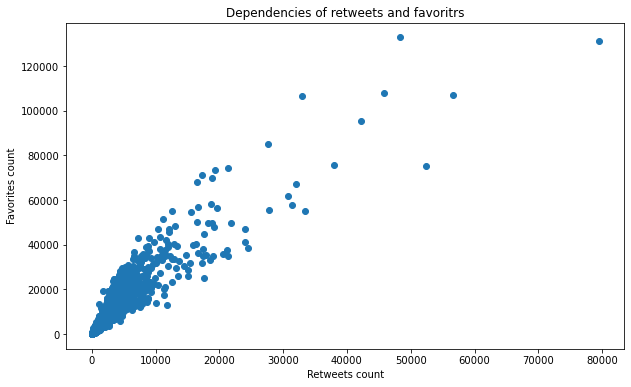

The plot above clearly displays those dependencies. Also, let's look at the distribution of ratings.

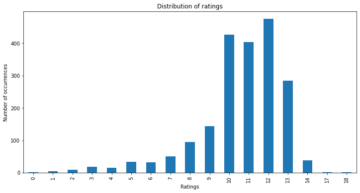

Also, I want to look is there any dependencies of ratings and likes. Plot down there have some biases based on my decisions in data cleaning stage, so ratings 17 and 18 could be ignored (i imputed those ratings manually in case that in original message rating's was above 100)

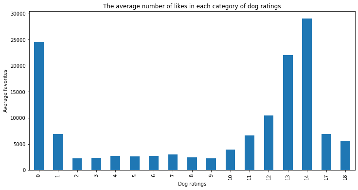

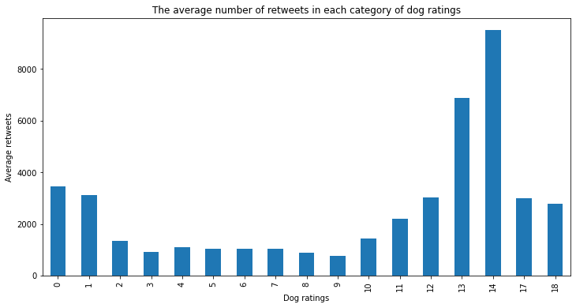

While working with those data I found a really interesting explanation of dog stages. So there 4 types of them: upper, puppo, floofer, and doggo. Question is - which stage has the highest average rating? Answer: doggo + puppo. Little explanation, this stage we receive if we have 2 types of dogs in the picture. And on average, people give these pictures high marks and a lot of likes. Pictures below.

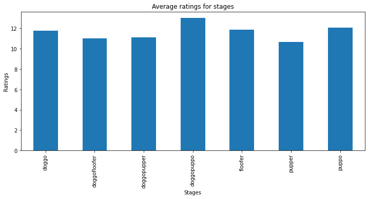

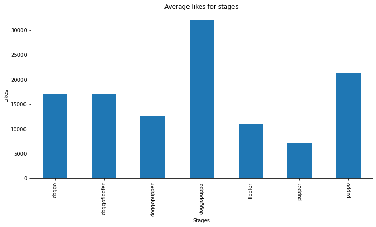

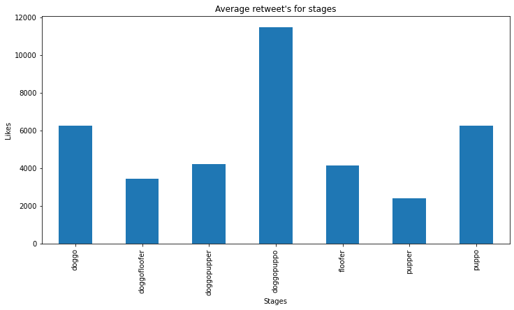

Let's speek about breed representation in analyzing data. What breed have most like's, ratings, finally, what is most common breed? Disclaimer: while we try to find what breed have dog on picture we use some machine learning techniques, and breed has been identified with some probability. For the formation of graphs, I have chosen a 70% threshold, i.e. if the breed is determined with 70% accuracy, I believe that it is a dog of this particular breed. For me, before making that analysis I thought that most ratings will have a golden retriever, but let's look at plots down there.

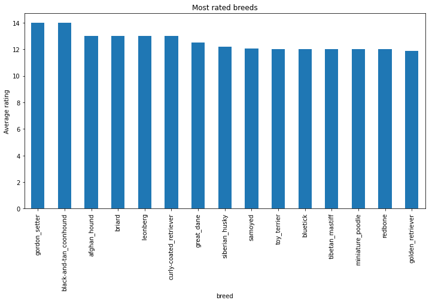

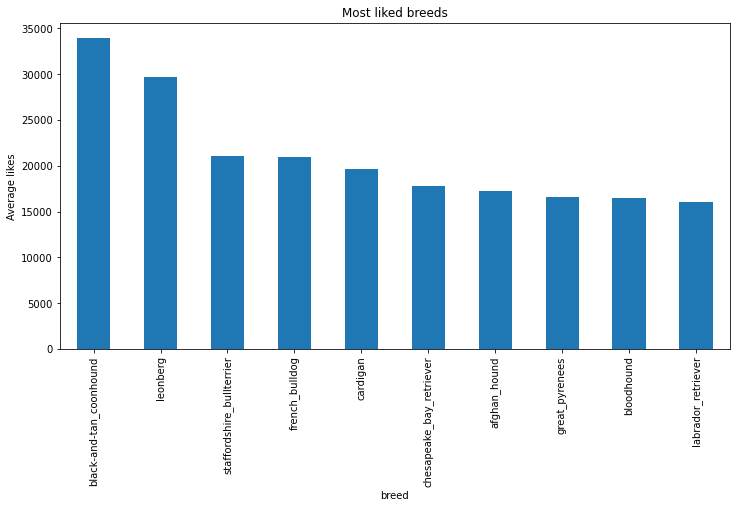

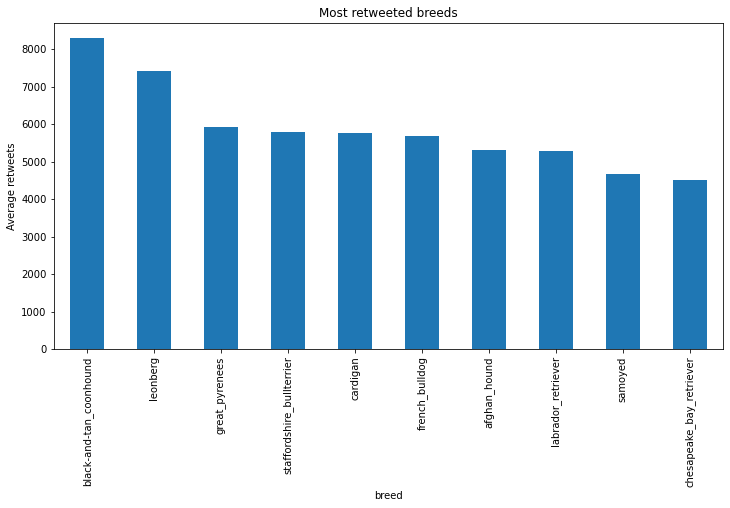

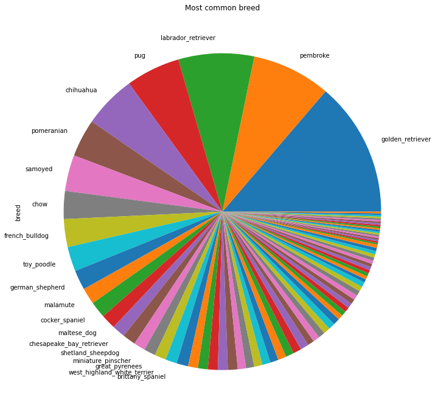

### Conclusion

That was an interesting assessment, that help's me muster skills in data wrangling and also helps me find some interesting information about dog stages and about data provided, like:

- Dependencies of retweets and favorites: proven
- Dependencies of ratings likes and retweets: prove
- What stage of dog do people prefer: dog + puppy :)
- And finally what most common and what most liked breed in our data: most common: golden retriever, most liked: black-and-tan coonhound